# Orange Juice Purchase Analysis: Minute Maid vs Citrus Hill

Evan Baker

11/29/2021

## Introduction:

As requested I have completed the analysis on orange juice purchases, specifically the Minute Maid and Citrus Hill brands. The goal of this analysis is to understand the effect of different variables on a customer’s purchase decision, gain insight on how to boost Minute Maid sales, and create a predictive model that can accurately predict a customer’s purchase outcome.

## Methods & Analysis

To complete this analysis I have calculated correlations, tested different logistic models, and developed a SVM prediction model.

### Data Methods

With the given data set I found that many of the variables were highly correlated with each other, due to the nature of how they were calculated. Most of this data set is made up of pricing data, much of which tells the same information but with respect to different variables. This was causing a poor fit and multicollinearity in logistic regressions encompassing all variables. The goal is to have a model in which the independent variables are not highly correlated, yet have a significant effect on the dependent variable. Eventually I was able to narrow down my model to three variables: PriceDiff, LoyalCH, and StoreID. These variables encompass price, loyalty, and location, which I believe to be a suitable scope to look at this topic through.

I did not alter any variables for this analysis, but I did add some binary variables indicating a Minute Maid or Citrus Hills Purchase. These variables are used in place of ‘Purchase’ in some calculations for ease of use.

## Reccomendations & Findings

### Findings

- Minute Maid Customers are price sensitive. Demand will fall as price goes up.
- Customers respond positively to Minute Maid specials
- If a customer is loyal to Citrus Hill, based on purchase history, they are likely not to buy or switch to Minute Maid even with pricing changes.

### Reccomendations

- Manage and track the pricing of Minute Maid more closely. Avoid any extra markup on price. I am happy to hop in a meeting with the pricing team and my findings on OJ pricing and purchase decsions.
- Customer’s respond positively to Minute Maid Specials, run specials as needed to bolster sales and compete with Citrus Hills.
- Obtain more customer segmenting data in order to build a more comprehensive customer profile and stronger predictive models. With more data on Customer’s we can access a much larger range of variables and create more opportunities and insights.

### Summary

There is a decent amount correlation between price changes and Minute Maid sales. The customer seems to be reluctant to spend money on Minute Maid, yet Citrus Hill OJ is not affected by price nearly as much. This could be a quality or branding issue, but for our purposes we should be paying very close attention to price of Minute Maid. I am aware that we are aiming to keep a certain profit margin though. Customers respond well to specials, and perhaps we can do some market basket analysis to understand what customers are buying with Minute Maid. There could be opportunity to change placement of products with respect to Minute Maid, or offer discounts and coupons on groups of items. I would also reccomend some targeted advertising towards Citrus Hill customers to see if we can pull any over to the Minute Maid side. We would need some more information on these customer segments, but diving into why these customers are loyal to Citrus Hill could provide valuable insights on the orange juice customer segment in general. Store 7 also seems to have a negative correlation with Minute Maid sales, we should reach out to the store manager to see if this is a physical issue.

# Complete Code & Models

### PACKAGE LOADING

```r
library(tidyverse)
library(ggcorrplot)
library(psych)
library(caret)
library(rminer)
library(kernlab)
library(plotROC)
library(e1071)
```

### DATA IMPORT & CLEANING

```r
#import data
OJ<-read.csv(url("http://data.mishra.us/files/OJ.csv"))
#create binary indicator for MM & CH purchases, and 'Store7'
OJ <- OJ %>%
            mutate(S7 = case_when(endsWith(Store7, "No") ~ 0,endsWith(Store7, "Yes") ~ 1)) %>%
            mutate(MMPurchase = case_when(endsWith(Purchase, "CH") ~ 0,endsWith(Purchase, "MM") ~ 1)) %>%
            mutate(CHPurchase = case_when(endsWith(Purchase, "CH") ~ 1,endsWith(Purchase, "MM") ~ 0))
#factor 'Purchase' & 'Store7'
OJ$Purchase <- as.factor(OJ$Purchase)
OJ$Store7 <- as.factor(OJ$Store7)
OJ$StoreID <- factor(OJ$StoreID, levels = c(1,2,3,4,7))

#create numeric df, also create binary 'Store7' variable
OJnumeric <- OJ %>%
  select_if(is.numeric)

str(OJ)
```

```
## 'data.frame':    1070 obs. of  21 variables:
##  $ Purchase      : Factor w/ 2 levels "CH","MM": 1 1 1 2 1 1 1 1 1 1 ...
##  $ WeekofPurchase: int  237 239 245 227 228 230 232 234 235 238 ...
##  $ StoreID       : Factor w/ 5 levels "1","2","3","4",..: 1 1 1 1 5 5 5 5 5 5 ...
##  $ PriceCH       : num  1.75 1.75 1.86 1.69 1.69 1.69 1.69 1.75 1.75 1.75 ...
##  $ PriceMM       : num  1.99 1.99 2.09 1.69 1.69 1.99 1.99 1.99 1.99 1.99 ...
##  $ DiscCH        : num  0 0 0.17 0 0 0 0 0 0 0 ...
##  $ DiscMM        : num  0 0.3 0 0 0 0 0.4 0.4 0.4 0.4 ...
##  $ SpecialCH     : int  0 0 0 0 0 0 1 1 0 0 ...
##  $ SpecialMM     : int  0 1 0 0 0 1 1 0 0 0 ...
##  $ LoyalCH       : num  0.5 0.6 0.68 0.4 0.957 ...
##  $ SalePriceMM   : num  1.99 1.69 2.09 1.69 1.69 1.99 1.59 1.59 1.59 1.59 ...
##  $ SalePriceCH   : num  1.75 1.75 1.69 1.69 1.69 1.69 1.69 1.75 1.75 1.75 ...
##  $ PriceDiff     : num  0.24 -0.06 0.4 0 0 0.3 -0.1 -0.16 -0.16 -0.16 ...
##  $ Store7        : Factor w/ 2 levels "No","Yes": 1 1 1 1 2 2 2 2 2 2 ...
##  $ PctDiscMM     : num  0 0.151 0 0 0 ...
##  $ PctDiscCH     : num  0 0 0.0914 0 0 ...
##  $ ListPriceDiff : num  0.24 0.24 0.23 0 0 0.3 0.3 0.24 0.24 0.24 ...
##  $ STORE         : int  1 1 1 1 0 0 0 0 0 0 ...
##  $ S7            : num  0 0 0 0 1 1 1 1 1 1 ...
##  $ MMPurchase    : num  0 0 0 1 0 0 0 0 0 0 ...
##  $ CHPurchase    : num  1 1 1 0 1 1 1 1 1 1 ...
```

### DATA EXPLORATION & VISUALIZATION

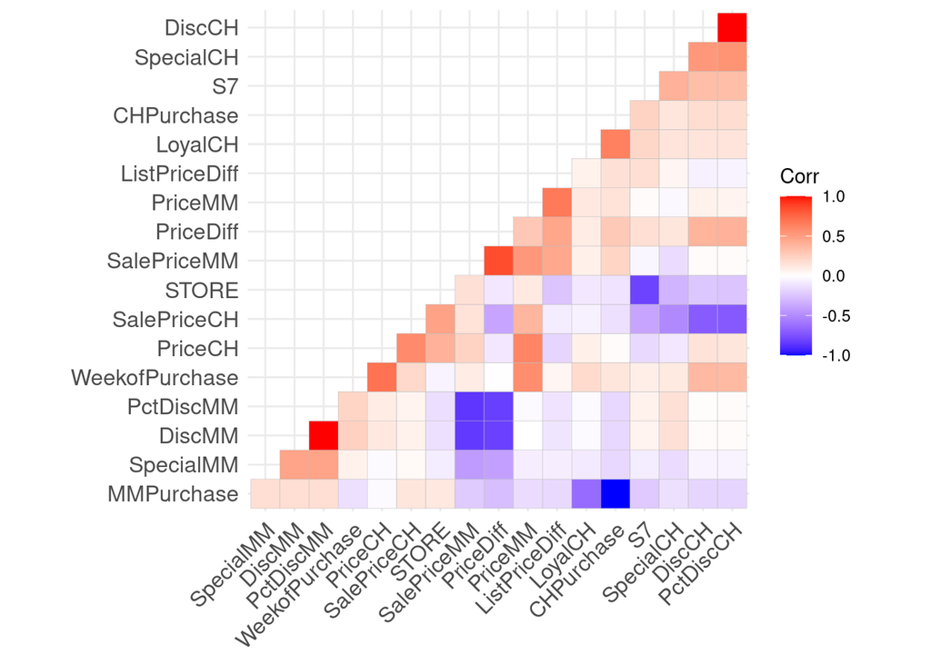

```r
#take a look at correlation of all numeric variables
newcorr <- round(cor(OJnumeric),2)
ggcorrplot(newcorr, hc.order = TRUE, type = "lower")
```

```r
#pricing variables correlation with 'MMPurchase'
OJpricing <- OJ %>% select(PriceCH,PriceMM,DiscCH,DiscMM,SalePriceMM,SalePriceCH,PriceDiff)
cor(OJ$MMPurchase,OJpricing)
```

```
##          PriceCH    PriceMM    DiscCH    DiscMM SalePriceMM SalePriceCH
## [1,] -0.02302084 -0.1491803 -0.181249 0.1669214  -0.2205844   0.1321257
##       PriceDiff
## [1,] -0.2750222
```

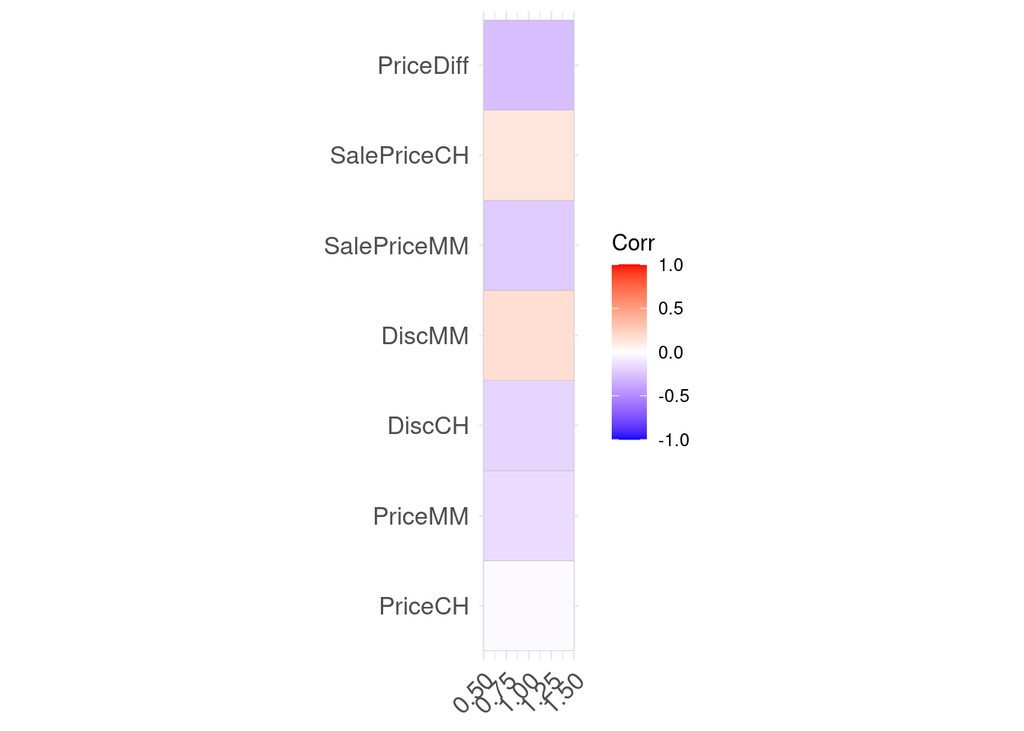

```r
ggcorrplot(cor(OJ$MMPurchase,OJpricing))
```

```r
#other variables interesting
cor(OJ$MMPurchase,OJ$LoyalCH)
```

```
## [1] -0.6405824
```

```r
cor(OJ$MMPurchase,OJ$S7)
```

```
## [1] -0.2307681
```

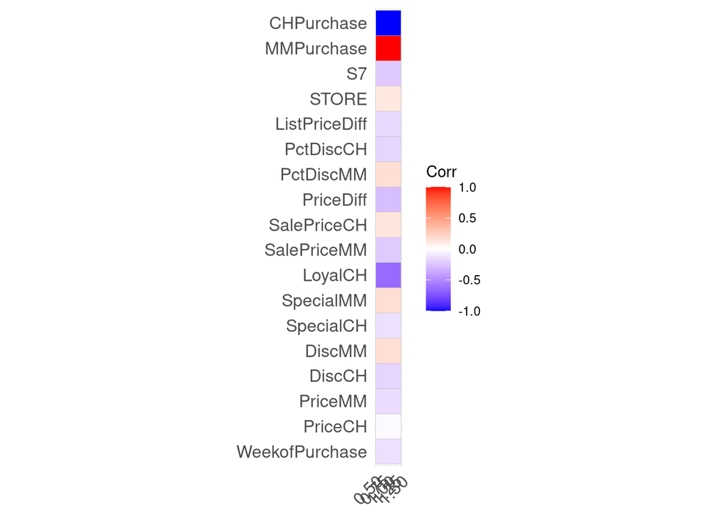

```r
#targeted look at every numeric variable's correlation with 'MMPurchase'
corrlist <- cor(OJnumeric$MMPurchase,OJnumeric)
ggcorrplot(corrlist)
```

```r
#Correlations of PctDisc and OJ purchases
cor(OJ$PctDiscMM,OJ$PctDiscCH)
```

```
## [1] 0.01531748
```

```r
cor(OJ$PctDiscMM,OJ$MMPurchase)
```

```
## [1] 0.1664585
```

```r
cor(OJ$PctDiscCH,OJ$CHPurchase)
```

```
## [1] 0.1822014
```

```r
cor(OJ$PriceMM,OJ$MMPurchase)
```

```
## [1] -0.1491803
```

```r
cor(OJ$PriceCH,OJ$CHPurchase)
```

```
## [1] 0.02302084
```

```r
cor(OJ$SpecialMM,OJ$MMPurchase)
```

```
## [1] 0.1747838
```

### EXPLORING LOGISTIC REGRESSION MODELS

```r
#explore models with AIC score.
#best vars found: {PriceDiff + LoyalCH + StoreID} AIC: 839

#Model 1: Uses all variables except binary purchase indicators
Model1 <- glm(Purchase ~ . - MMPurchase - CHPurchase, data = OJ, family = binomial(link = "logit"))

#Model 2: Uses 'PriceDiff', 'LoyalCH', and 'StoreID'. Simplest model with lowest AIC found
Model2 <- glm(Purchase ~ PriceDiff + LoyalCH + StoreID, data = OJ, family = binomial(link = "logit"))

#Model 3: Uses everything but removes correlated pricing data
Model3 <- glm(Purchase ~ . - MMPurchase - CHPurchase - SalePriceMM - SalePriceCH - PctDiscMM - PctDiscCH, data = OJ, family = binomial(link = "logit"))

print(paste("Model 1:", AIC(Model1), "Model 2:",
              AIC(Model2), "Model 3:", AIC(Model3)))
```

```
## [1] "Model 1: 846.247904772717 Model 2: 839.810361915065 Model 3: 848.99586228119"
```

```r
#I will use Model2 to create a predictive model as it produces the lowest AIC score

#Find the model summaries below
summary(Model1)
```

```
##
## Call:
## glm(formula = Purchase ~ . - MMPurchase - CHPurchase, family = binomial(link = "logit"),
##     data = OJ)
##
## Deviance Residuals:
##     Min       1Q   Median       3Q      Max
## -2.7518  -0.5413  -0.2306   0.5265   2.8005
##
## Coefficients: (7 not defined because of singularities)
##                 Estimate Std. Error z value Pr(>|z|)
## (Intercept)      4.90958    2.08163   2.359  0.01835 *
## WeekofPurchase  -0.01123    0.01137  -0.988  0.32320
## StoreID2        -0.04713    0.29067  -0.162  0.87119
## StoreID3        -0.21282    0.39069  -0.545  0.58595
## StoreID4        -0.53164    0.41906  -1.269  0.20456
## StoreID7        -0.64787    0.28809  -2.249  0.02453 *
## PriceCH          4.56495    1.88740   2.419  0.01558 *
## PriceMM         -3.68490    0.91548  -4.025 5.69e-05 ***
## DiscCH          11.27171   18.82388   0.599  0.54931
## DiscMM          25.44305    9.31290   2.732  0.00629 **
## SpecialCH        0.26336    0.34304   0.768  0.44265
## SpecialMM        0.31350    0.27586   1.136  0.25576
## LoyalCH         -6.24874    0.41040 -15.226  < 2e-16 ***
## SalePriceMM           NA         NA      NA       NA
## SalePriceCH           NA         NA      NA       NA
## PriceDiff             NA         NA      NA       NA
## Store7Yes             NA         NA      NA       NA
## PctDiscMM      -48.55687   19.50068  -2.490  0.01277 *
## PctDiscCH      -28.26083   35.57517  -0.794  0.42696
## ListPriceDiff         NA         NA      NA       NA
## STORE                 NA         NA      NA       NA
## S7                    NA         NA      NA       NA
## ---
## Signif. codes:  0 '***' 0.001 '**' 0.01 '*' 0.05 '.' 0.1 ' ' 1
##
## (Dispersion parameter for binomial family taken to be 1)
##
##     Null deviance: 1430.85  on 1069  degrees of freedom
## Residual deviance:  816.25  on 1055  degrees of freedom
## AIC: 846.25
##
## Number of Fisher Scoring iterations: 5
```

```r
summary(Model2)
```

```
##
## Call:
## glm(formula = Purchase ~ PriceDiff + LoyalCH + StoreID, family = binomial(link = "logit"),
##     data = OJ)
##
## Deviance Residuals:
##     Min       1Q   Median       3Q      Max
## -2.8023  -0.5503  -0.2373   0.5302   2.8033
##
## Coefficients:
##             Estimate Std. Error z value Pr(>|z|)
## (Intercept)  3.33882    0.29734  11.229  < 2e-16 ***
## PriceDiff   -2.83003    0.35130  -8.056  7.9e-16 ***
## LoyalCH     -6.21427    0.40214 -15.453  < 2e-16 ***
## StoreID2     0.14423    0.27192   0.530   0.5958
## StoreID3     0.05241    0.29624   0.177   0.8596
## StoreID4    -0.23586    0.33279  -0.709   0.4785
## StoreID7    -0.67342    0.26324  -2.558   0.0105 *
## ---
## Signif. codes:  0 '***' 0.001 '**' 0.01 '*' 0.05 '.' 0.1 ' ' 1
##
## (Dispersion parameter for binomial family taken to be 1)
##
##     Null deviance: 1430.85  on 1069  degrees of freedom
## Residual deviance:  825.81  on 1063  degrees of freedom
## AIC: 839.81
##
## Number of Fisher Scoring iterations: 5
```

```r
summary(Model3)
```

```
##
## Call:
## glm(formula = Purchase ~ . - MMPurchase - CHPurchase - SalePriceMM -
##     SalePriceCH - PctDiscMM - PctDiscCH, family = binomial(link = "logit"),
##     data = OJ)
##
## Deviance Residuals:
##     Min       1Q   Median       3Q      Max
## -2.7940  -0.5480  -0.2360   0.5366   2.8046
##
## Coefficients: (5 not defined because of singularities)
##                 Estimate Std. Error z value Pr(>|z|)
## (Intercept)     2.607191   1.841834   1.416 0.156910
## WeekofPurchase -0.006804   0.011265  -0.604 0.545858
## StoreID2        0.114697   0.278030   0.413 0.679947
## StoreID3       -0.089989   0.387110  -0.232 0.816178
## StoreID4       -0.414899   0.415458  -0.999 0.317962
## StoreID7       -0.628815   0.288834  -2.177 0.029475 *
## PriceCH         4.649995   1.864492   2.494 0.012632 *
## PriceMM        -3.252976   0.876417  -3.712 0.000206 ***
## DiscCH         -3.523131   1.109373  -3.176 0.001494 **
## DiscMM          2.317951   0.532891   4.350 1.36e-05 ***
## SpecialCH       0.107952   0.331034   0.326 0.744343
## SpecialMM       0.265258   0.274707   0.966 0.334242
## LoyalCH        -6.177652   0.406844 -15.184  < 2e-16 ***
## PriceDiff             NA         NA      NA       NA
## Store7Yes             NA         NA      NA       NA
## ListPriceDiff         NA         NA      NA       NA
## STORE                 NA         NA      NA       NA
## S7                    NA         NA      NA       NA
## ---
## Signif. codes:  0 '***' 0.001 '**' 0.01 '*' 0.05 '.' 0.1 ' ' 1
##
## (Dispersion parameter for binomial family taken to be 1)
##
##     Null deviance: 1430.9  on 1069  degrees of freedom
## Residual deviance:  823.0  on 1057  degrees of freedom
## AIC: 849
##
## Number of Fisher Scoring iterations: 5
```

### PREDICTIVE LOGISTIC REGRESSION MODEL

```r
set.seed(801)
#split data
split = .7
train_index <- sample(1:nrow(OJ), split * nrow(OJ))
test_index <- setdiff(1:nrow(OJ), train_index)

train_data <- OJ[train_index,]
test_data <- OJ[test_index,]

#Model with best AIC from Data Exploration
predictionModel <- glm(Purchase ~ PriceDiff + LoyalCH + StoreID, data = train_data,
family = binomial(link = "logit"))

test_data$prediction <- predict(predictionModel,
newdata = test_data, type = "response")

#set threshold of 50% for generated probabilties above
test_data$binary_prediction <- ifelse(test_data$prediction >.5, 1,0)

#caclulate binary 'correct' column that indicates if prediction is correct
test_data <- test_data %>% mutate(correct = case_when(binary_prediction == MMPurchase ~ 1,binary_prediction != MMPurchase ~ 0))
accuracy <- sum(test_data$correct)/nrow(test_data)
print(paste("The accuracy of the model on the test_data is:",round(accuracy,3)))
```

```
## [1] "The accuracy of the model on the test_data is: 0.838"
```

### PREDICTIVE SVM

```r
svmModel <- svm(Purchase ~ PriceDiff + LoyalCH + StoreID, data = train_data)
svmPredict <- predict(svmModel, test_data, type = "response")

svmTestData <- test_data %>% select(-correct) %>%mutate(svmPrediction = svmPredict) %>% mutate(svmCorrect = case_when(svmPrediction == Purchase ~ 1, svmPrediction != Purchase ~ 0))
str(svmTestData)
```

```
## 'data.frame':    321 obs. of  25 variables:
##  $ Purchase         : Factor w/ 2 levels "CH","MM": 1 1 1 2 2 1 1 1 1 1 ...
##  $ WeekofPurchase   : int  235 240 276 240 269 258 259 272 274 278 ...
##  $ StoreID          : Factor w/ 5 levels "1","2","3","4",..: 5 5 5 1 2 1 5 5 5 5 ...
##  $ PriceCH          : num  1.75 1.86 1.99 1.75 1.86 1.76 1.86 1.86 1.86 2.06 ...
##  $ PriceMM          : num  1.99 2.09 2.13 1.99 2.18 2.18 2.18 2.13 2.13 2.13 ...
##  $ DiscCH           : num  0 0 0 0 0 0 0 0 0.47 0 ...
##  $ DiscMM           : num  0.4 0 0.54 0.3 0 0 0 0 0.54 0 ...
##  $ SpecialCH        : int  0 0 0 0 0 0 0 0 1 0 ...
##  $ SpecialMM        : int  0 0 1 1 0 0 0 0 0 0 ...
##  $ LoyalCH          : num  0.982 0.989 0.993 0.5 0.32 ...
##  $ SalePriceMM      : num  1.59 2.09 1.59 1.69 2.18 2.18 2.18 2.13 1.59 2.13 ...
##  $ SalePriceCH      : num  1.75 1.86 1.99 1.75 1.86 1.76 1.86 1.86 1.39 2.06 ...
##  $ PriceDiff        : num  -0.16 0.23 -0.4 -0.06 0.32 0.42 0.32 0.27 0.2 0.07 ...
##  $ Store7           : Factor w/ 2 levels "No","Yes": 2 2 2 1 1 1 2 2 2 2 ...
##  $ PctDiscMM        : num  0.201 0 0.254 0.151 0 ...
##  $ PctDiscCH        : num  0 0 0 0 0 ...
##  $ ListPriceDiff    : num  0.24 0.23 0.14 0.24 0.32 0.42 0.32 0.27 0.27 0.07 ...
##  $ STORE            : int  0 0 0 1 2 1 0 0 0 0 ...
##  $ S7               : num  1 1 1 0 0 0 1 1 1 1 ...
##  $ MMPurchase       : num  0 0 0 1 1 0 0 0 0 0 ...
##  $ CHPurchase       : num  1 1 1 0 0 1 1 1 1 1 ...
##  $ prediction       : num  0.0607 0.0185 0.1129 0.6283 0.595 ...
##  $ binary_prediction: num  0 0 0 1 1 0 0 0 0 0 ...
##  $ svmPrediction    : Factor w/ 2 levels "CH","MM": 1 1 1 2 2 1 1 1 1 1 ...
##   ..- attr(*, "names")= chr [1:321] "9" "11" "13" "17" ...
##  $ svmCorrect       : num  1 1 1 1 1 1 1 1 1 1 ...
```

```r
svmAccuracy <- sum(svmTestData$svmCorrect)/nrow(svmTestData)
print(paste("The accuracy of the SVM model on the test_data is:",round(svmAccuracy,3)))
```

```
## [1] "The accuracy of the SVM model on the test_data is: 0.844"
```